# Ch2: R-ETL: dplyr

劉佳欣 Rafe C. H. Liu / Johnson Hsieh / George Chao

Contact｜[Linkedin](http://tw.linkedin.com/in/rafechliu)

# 0. R-Review

### 最重要的小事

- 程式『語言』
- Working directory
  - `getwd()`: get working directory
  - `setwd()`
- 讀檔之前，先觀察檔案
  - 編碼通常都是 `UTF8` 或 `BIG5`
  - Linux, Darwin: “UTF-8”
  - Windows: “BIG-5”
- library function
  - 依照不同檔案格式選擇
  - `readLines`, `read.csv`….

### Packages for today

- 套件安裝 / `install.packages()`
  - magrittr
  - dplyr
  - reshape2
- 載入套件 / `library("package.name")`

### read data

- Concept

```r
raw <- readLines('檔案路徑', encoding = "BIG-5")
```

- Tips: 轉換編碼並存檔

```r
# 從big5轉utf8
raw2 <- iconv(raw, from = "BIG-5", to = "UTF-8")

# 存檔囉～～
write.csv(file = "ubikeweatherutf8.csv", x = raw2, fileEncoding = "UTF-8")
```

### 本日資料檔

ubike x weather 資料檔(右鍵另存新檔)

- [big5 (WIN)](https://github.com/snexuz/2016DSP_dplyr/raw/master/data/ubike-weather-big5.csv)
- [utf8 (MAC, LINUX)](https://github.com/snexuz/2016DSP_dplyr/raw/master/data/ubike-weather-utf8.csv)

```r
# 必先確認 Working Directory!
# getwd(), setwd()

# read.csv
ubike <- read.csv(file = "./data/ubike-weather-big5.csv",
          colClasses = c("factor","integer","integer","factor","factor",
                         "numeric","numeric","integer","numeric","integer",
                         "integer","numeric","numeric", "integer","integer",
                         "numeric","numeric","numeric", "numeric","numeric",
                         "numeric", "numeric","numeric"),
          fileEncoding = 'BIG-5',
          stringsAsFactors = F)

# 以 colClasses 控制每個欄位的 class，這可使讀檔加速
# 以 fileEncoding 定義檔案編碼
```

### 把欄位換成中文

- `CAUTION!: 雖然欄位名稱可以換成中文，但是不建議`

```r
colnames(ubike) <- c("日期","時間","場站代號","場站區域","場站名稱",
                     "經度","緯度","總停車格","平均車輛數","最大車輛數",
                     "最小車輛數","車輛數標準差","平均空位數","最大空位數","最小空位數",
                     "空位數標準差","氣溫","最高溫","最低溫","溼度",
                     "氣壓","最大風速","降雨量")
```

- 欄位中文英文對照表

```r
ubike <- read.csv(file = "./data/ubike-weather-big5.csv",
          colClasses = c("factor","integer","integer","factor","factor",
                         "numeric","numeric","integer","numeric","integer",
                         "integer","numeric","numeric", "integer","integer",
                         "numeric","numeric","numeric", "numeric","numeric",
                         "numeric", "numeric","numeric"),
          fileEncoding = 'BIG-5',
          stringsAsFactors = F)

chin <- c("日期","時間","場站代號","場站區域","場站名稱","經度","緯度",
          "總停車格","平均車輛數","最大車輛數","最小車輛數","車輛數標準差","平均空位數","最大空位數",
          "最小空位數","空位數標準差","氣溫","最高溫","最低溫","溼度","氣壓",
          "最大風速","降雨量")

coln <- data.frame(matrix(data="", ncol=4, nrow=11), stringsAsFactors = FALSE)
coln$X1 <- chin[1:11]
coln$X2 <- colnames(ubike)[1:11]
coln$X3[1:10] <- chin[12:21]
coln$X4[1:10] <- colnames(ubike)[12:21]
```

| 欄位名稱 | 代號 | 欄位名稱 | 代號 |
| --- | --- | --- | --- |
| 日期 | date | 車輛數標準差 | std.sbi |
| 時間 | hour | 平均空位數 | avg.bemp |
| 場站代號 | sno | 最大空位數 | max.bemp |
| 場站區域 | sarea | 最小空位數 | min.bemp |
| 場站名稱 | sna | 空位數標準差 | std.bemp |
| 經度 | lat | 氣溫 | temp |
| 緯度 | lng | 最高溫 | max.temp |
| 總停車格 | tot | 最低溫 | min.temp |
| 平均車輛數 | avg.sbi | 溼度 | humidity |
| 最大車輛數 | max.sbi | 氣壓 | pressure |
| 最小車輛數 | min.sbi |  |  |

### 取值- 座標

```r
# structure, summary of ubike dataset
str(ubike)

# head可以取出前幾列
head(ubike)

# tail可以取最後幾列
tail(ubike)

# 利用座標來取值，第一個數表示列位，第二個數表示欄位
ubike[3,2]

# 可一次選擇多列多欄
ubike[c(3:4), c(2:5,7)]

# 加上負號可剔除列位欄位
ubike[c(3:4), -c(6:21)]
```

### 取值- 指定欄位

```r
ubike[,4]

ubike[,"sna"]

ubike[["sna"]]

ubike$場站名稱
```

**Quiz:** 以下顯示？

```r
ubike[ubike$sna %in% c("台北市災害應變中心", "世貿三館"), ]
```

# 1. Manipulate data: ETL

## 1.1. magrittr, dplyr

- 壓縮的程式碼不好讀
- 展開的程式碼會產生很多暫存變數
- 套件 `magrittr` 解決了這個問題
- Pipeline style

```r
# OLD school
ans1 <- ubike$sna
ans1.1 <- unique(ans1) # unique可列出所有不重複的項目
print(head(ans1.1, n = 10))

# pipeline style
library(magrittr)
ubike$sna %>%
  unique() %>% head(n = 10) %>%
  print()
```

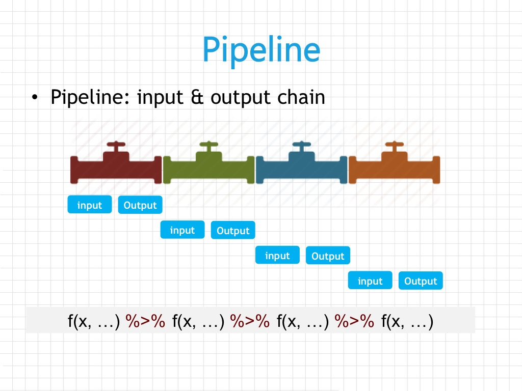

### dplyr

- 讓 R 使用者可以用更有彈性的方式來處理資料
- 整合 `magrittr` pipeline
- 針對 `data.frame` 做設計（名稱中的`d`）
- 設計理念
  - Step by step
  - 處理速度直覺又快
  - 支援異質資料源（`data.frame` 或資料庫中的表格）
  - 結合資料整理工具優點（ex. Excel, SQL）

### 官方文件：`vignette`

- 更詳細的 dplyr 介紹可以閱讀 dplyr 的小論文
- R 的開發者會針對一個主題撰寫小論文做介紹

```r
vignette(all = TRUE, package = "dplyr")

vignette("introduction", package = "dplyr")
```

### dplyr 常用指令

- `filter` 對列做篩選
- `select` 對欄做篩選
- `mutate` 更改欄或新增欄
- `arrange` 排列
- `group_by`+`summarise` 依照類別處理
- 合併欄位

## 1.2. 範例實作

```r
library(dplyr)

head(ubike)

select(ubike, hour, sarea, sna, avg.sbi) %>%
  filter(sarea == '中和區' & hour == 7) %>%
  mutate(avg.sbi = floor(avg.sbi))

select(ubike, hour, sarea, sna, avg.sbi) %>%
  filter(sarea == '中和區' & hour == 7) %>%
  group_by(hour, sarea, sna) %>%
  summarise(avg = mean(avg.sbi) %>% round()) %>%
  arrange(avg %>% desc())
```

### select

```r
select(ubike, hour, sarea, sna, avg.sbi)
```

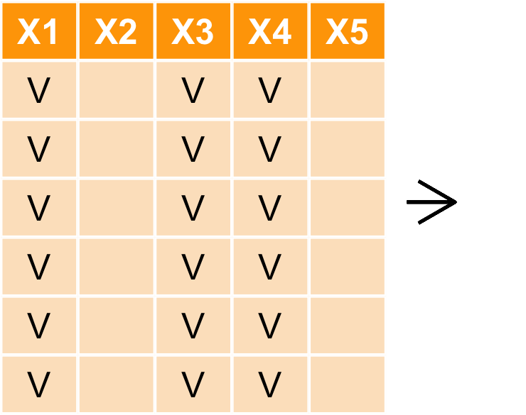

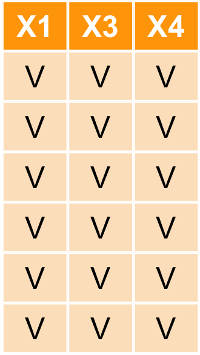

- 「選擇」時間、場站區域、場站名稱、平均車輛數

| hour | sarea | sna | avg.sbi |
| --- | --- | --- | --- |
| 15 | 大安區 | 捷運國父紀念館站(2號出口) | 24.000 |
| 15 | 信義區 | 台北市政府 | 10.333 |
| 15 | 信義區 | 市民廣場 | 39.333 |
| 15 | 信義區 | 興雅國中 | 34.167 |
| 15 | 信義區 | 世貿二館 | 31.333 |
| 15 | 信義區 | 信義廣場(台北101) | 23.571 |

### filter

```r
select(ubike, hour, sarea, sna, avg.sbi) %>%
  filter(sarea == '中和區' & hour == 7)
```

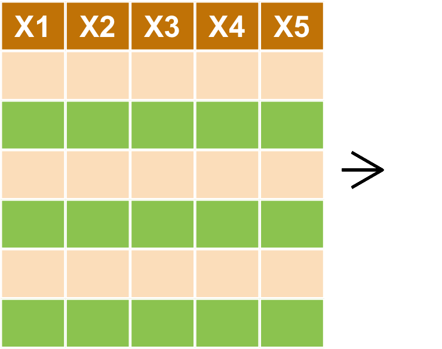

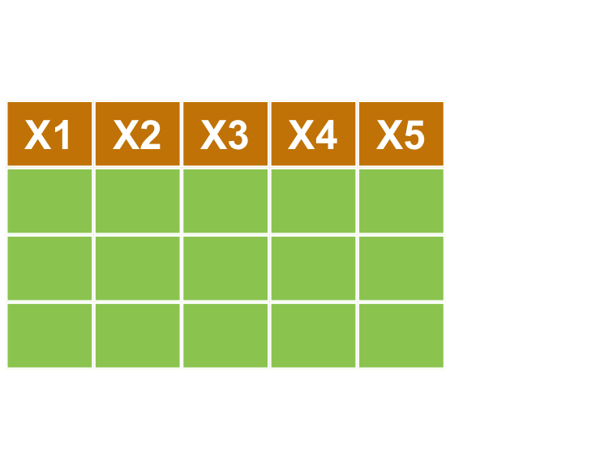

- 「篩選」出中和區的資料

| hour | sarea | sna | avg.sbi |
| --- | --- | --- | --- |
| 7 | 中和區 | 秀山國小 | 0.000 |
| 7 | 中和區 | 捷運永安市場站 | 1.733 |
| 7 | 中和區 | 中和公園 | 0.267 |
| 7 | 中和區 | 秀山國小 | 33.800 |
| 7 | 中和區 | 捷運永安市場站 | 6.467 |
| 7 | 中和區 | 中和公園 | 4.600 |
| 7 | 中和區 | 秀山國小 | 37.400 |
| 7 | 中和區 | 捷運永安市場站 | 12.867 |
| 7 | 中和區 | 中和公園 | 1.467 |
| 7 | 中和區 | 秀山國小 | 31.867 |
| 7 | 中和區 | 捷運永安市場站 | 19.267 |
| 7 | 中和區 | 中和公園 | 29.067 |
| 7 | 中和區 | 捷運永安市場站 | 13.600 |
| 7 | 中和區 | 中和公園 | 6.133 |
| 7 | 中和區 | 秀山國小 | 38.600 |
| 7 | 中和區 | 秀山國小 | 33.000 |
| 7 | 中和區 | 捷運永安市場站 | 1.600 |
| 7 | 中和區 | 中和公園 | 9.200 |

### mutate

```r
select(ubike, hour, sarea, sna, avg.sbi) %>%
  filter(sarea == '中和區' & hour == 7) %>%
  mutate(avg.sbi = floor(avg.sbi))
```

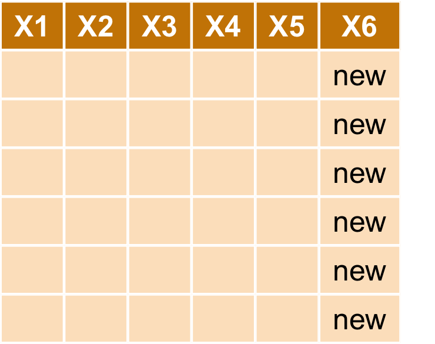

| hour | sarea | sna | avg.sbi |
| --- | --- | --- | --- |
| 7 | 中和區 | 秀山國小 | 0 |
| 7 | 中和區 | 捷運永安市場站 | 1 |
| 7 | 中和區 | 中和公園 | 0 |
| 7 | 中和區 | 秀山國小 | 33 |
| 7 | 中和區 | 捷運永安市場站 | 6 |
| 7 | 中和區 | 中和公園 | 4 |
| 7 | 中和區 | 秀山國小 | 37 |
| 7 | 中和區 | 捷運永安市場站 | 12 |
| 7 | 中和區 | 中和公園 | 1 |
| 7 | 中和區 | 秀山國小 | 31 |
| 7 | 中和區 | 捷運永安市場站 | 19 |
| 7 | 中和區 | 中和公園 | 29 |
| 7 | 中和區 | 捷運永安市場站 | 13 |
| 7 | 中和區 | 中和公園 | 6 |
| 7 | 中和區 | 秀山國小 | 38 |
| 7 | 中和區 | 秀山國小 | 33 |
| 7 | 中和區 | 捷運永安市場站 | 1 |
| 7 | 中和區 | 中和公園 | 9 |

### group_by

```r
select(ubike, hour, sarea, sna, avg.sbi) %>%
  filter(sarea == '中和區' & hour == 7) %>%
  group_by(hour, sarea, sna)
```

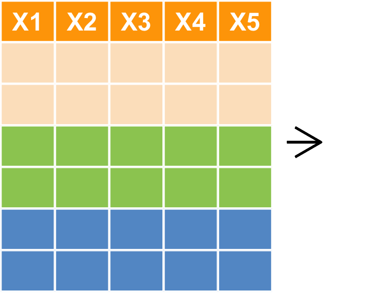

- 將資料依照某變數組成「群組」

| hour | sarea | sna | avg.sbi |
| --- | --- | --- | --- |
| 7 | 中和區 | 秀山國小 | 0.000 |
| 7 | 中和區 | 捷運永安市場站 | 1.733 |
| 7 | 中和區 | 中和公園 | 0.267 |
| 7 | 中和區 | 秀山國小 | 33.800 |
| 7 | 中和區 | 捷運永安市場站 | 6.467 |
| 7 | 中和區 | 中和公園 | 4.600 |
| 7 | 中和區 | 秀山國小 | 37.400 |
| 7 | 中和區 | 捷運永安市場站 | 12.867 |
| 7 | 中和區 | 中和公園 | 1.467 |
| 7 | 中和區 | 秀山國小 | 31.867 |
| 7 | 中和區 | 捷運永安市場站 | 19.267 |
| 7 | 中和區 | 中和公園 | 29.067 |
| 7 | 中和區 | 捷運永安市場站 | 13.600 |
| 7 | 中和區 | 中和公園 | 6.133 |
| 7 | 中和區 | 秀山國小 | 38.600 |
| 7 | 中和區 | 秀山國小 | 33.000 |
| 7 | 中和區 | 捷運永安市場站 | 1.600 |
| 7 | 中和區 | 中和公園 | 9.200 |

### summarise

```r
select(ubike, hour, sarea, sna, avg.sbi) %>%
  filter(sarea == '中和區' & hour == 7) %>%
  group_by(hour, sarea, sna) %>%
  summarise(avg = mean(avg.sbi) %>% round())
```

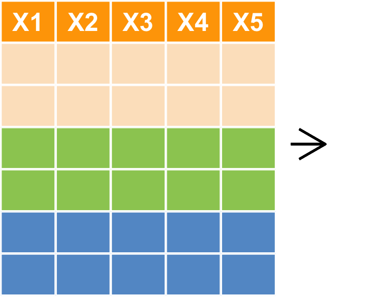

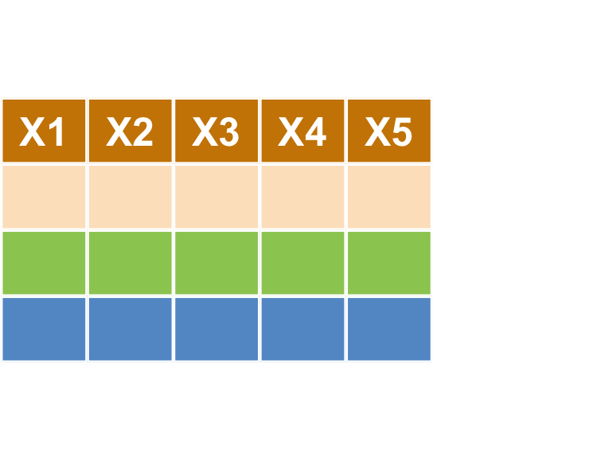

- 針對各組進行計算

| hour | sarea | sna | avg |
| --- | --- | --- | --- |
| 7 | 中和區 | 中和公園 | 8 |
| 7 | 中和區 | 捷運永安市場站 | 9 |
| 7 | 中和區 | 秀山國小 | 29 |

### arrange

```r
select(ubike, hour, sarea, sna, avg.sbi) %>%
  filter(sarea == '中和區' & hour == 7) %>%
  group_by(hour, sarea, sna) %>%
  summarise(avg = mean(avg.sbi) %>% round()) %>%
  arrange(avg %>% desc())
```

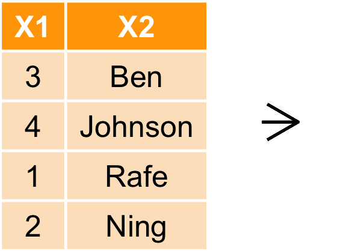

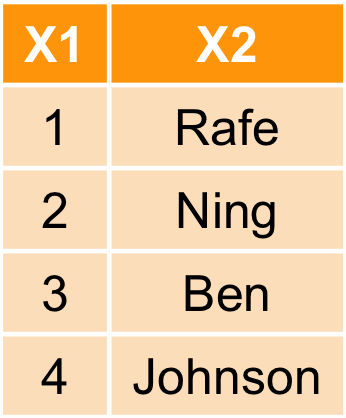

| hour | sarea | sna | avg |
| --- | --- | --- | --- |
| 7 | 中和區 | 秀山國小 | 29 |
| 7 | 中和區 | 捷運永安市場站 | 9 |
| 7 | 中和區 | 中和公園 | 8 |

**Quiz:** 小明發現住信義區的話，八點騎腳踏車就可以準時上班，還可以順便吃早餐，請幫忙找出信義區各車站八點車子最多的站

| hour | sarea | sna | avg |
| --- | --- | --- | --- |
| 8 | 信義區 | 捷運市政府站(3號出口) | 98 |
| 8 | 信義區 | 福德公園 | 31 |
| 8 | 信義區 | 興雅國中 | 31 |
| 8 | 信義區 | 台北市災害應變中心 | 30 |
| 8 | 信義區 | 世貿三館 | 29 |
| 8 | 信義區 | 世貿二館 | 29 |
| 8 | 信義區 | 吳興公車總站 | 29 |
| 8 | 信義區 | 三張犁 | 27 |
| 8 | 信義區 | 松山家商 | 26 |
| 8 | 信義區 | 市民廣場 | 24 |
| 8 | 信義區 | 信義廣場(台北101) | 23 |
| 8 | 信義區 | 捷運象山站 | 22 |
| 8 | 信義區 | 松德站 | 21 |
| 8 | 信義區 | 松德公園 | 20 |
| 8 | 信義區 | 台北市政府 | 16 |
| 8 | 信義區 | 五常公園 | 15 |
| 8 | 信義區 | 捷運台北101/世貿站 | 15 |
| 8 | 信義區 | 臺北醫學大學 | 14 |
| 8 | 信義區 | 仁愛逸仙路口 | 13 |
| 8 | 信義區 | 中強公園 | 10 |
| 8 | 信義區 | 捷運永春站(2號出口) | 8 |
| 8 | 信義區 | 永吉松信路口 | 8 |
| 8 | 信義區 | 基隆光復路口 | 5 |

[output not shown]

### bind

- `bind_rows(a,b)`
- `bind_cols(a,b)`

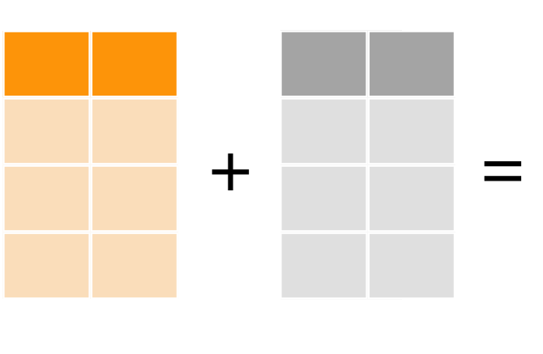

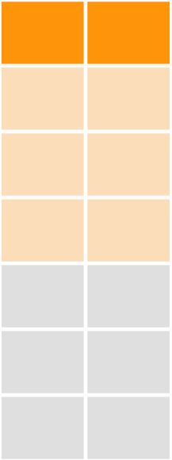

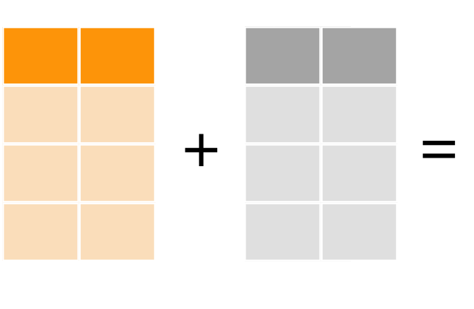

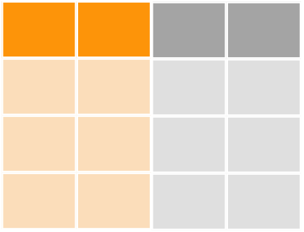

- bind_rows

```r
V1 <- data.frame('x1' = c("a", "b"), 'x2' = c(1, 2), stringsAsFactors = F)
V2 <- data.frame('x1' = c("c", "d"), 'x2' = c(3, 4), stringsAsFactors = F)
bind_rows(V1, V2)
```

```
  x1 x2
1  a  1
2  b  2
3  c  3
4  d  4
```

```r
# rbind(V1, V2)
```

- bind_cols

```r
bind_cols(V1, V2)
```

```
  x1 x2 x11 x21
1  a  1   c   3
2  b  2   d   4
```

```r
# cbind(V1, V2)
```

# 3. reshape2

- melt
  - wide format -> long format
- cast
  - long format -> wide format
  - `dcast` for data.frame
  - `acast` for vector, matrix and array

### melt

```r
data("WorldPhones")
WP <- as.data.frame(WorldPhones)
WP$year <- rownames(WP)
WP.melt <- melt(WP, id.var = 'year')
```

`WP$year <- rownames(WP)`

|  | N.Amer | Europe | Asia | S.Amer | Oceania | Africa | Mid.Amer | year |
| --- | --- | --- | --- | --- | --- | --- | --- | --- |
| 1951 | 45939 | 21574 | 2876 | 1815 | 1646 | 89 | 555 | 1951 |
| 1956 | 60423 | 29990 | 4708 | 2568 | 2366 | 1411 | 733 | 1956 |
| 1957 | 64721 | 32510 | 5230 | 2695 | 2526 | 1546 | 773 | 1957 |
| 1958 | 68484 | 35218 | 6662 | 2845 | 2691 | 1663 | 836 | 1958 |
| 1959 | 71799 | 37598 | 6856 | 3000 | 2868 | 1769 | 911 | 1959 |
| 1960 | 76036 | 40341 | 8220 | 3145 | 3054 | 1905 | 1008 | 1960 |

`WP.melt <- melt(WP, id.var = 'year')`

| year | variable | value |
| --- | --- | --- |
| 1951 | N.Amer | 45939 |
| 1956 | N.Amer | 60423 |
| 1957 | N.Amer | 64721 |
| 1958 | N.Amer | 68484 |
| 1959 | N.Amer | 71799 |
| 1960 | N.Amer | 76036 |

### cast

```r
WP.cast <- dcast(WP.melt, year ~ variable, value.var="value")
```

| year | N.Amer | Europe | Asia | S.Amer | Oceania | Africa | Mid.Amer |
| --- | --- | --- | --- | --- | --- | --- | --- |
| 1951 | 45939 | 21574 | 2876 | 1815 | 1646 | 89 | 555 |
| 1956 | 60423 | 29990 | 4708 | 2568 | 2366 | 1411 | 733 |
| 1957 | 64721 | 32510 | 5230 | 2695 | 2526 | 1546 | 773 |
| 1958 | 68484 | 35218 | 6662 | 2845 | 2691 | 1663 | 836 |
| 1959 | 71799 | 37598 | 6856 | 3000 | 2868 | 1769 | 911 |
| 1960 | 76036 | 40341 | 8220 | 3145 | 3054 | 1905 | 1008 |
| 1961 | 79831 | 43173 | 9053 | 3338 | 3224 | 2005 | 1076 |

# 4. 綜合演練

小明想知道信義區的腳踏車站晴天和雨天的使用率有何差別 提示： - `filter`、`mutate`、`select`、`group_by`、`summarise` - `dcast` - `arrange`

| sna | 晴天 | 雨天 |
| --- | --- | --- |
| 永吉松信路口 | 0.8720583 | 0.4744500 |
| 信義廣場(台北101) | 0.7952094 | 0.5329188 |
| 捷運永春站(2號出口) | 0.7888917 | 0.4466667 |
| 市民廣場 | 0.7369417 | 0.3238917 |
| 捷運台北101/世貿站 | 0.7294856 | 0.6448654 |
| 基隆光復路口 | 0.7277750 | 0.7589000 |
| 仁愛逸仙路口 | 0.6532895 | 0.5921053 |
| 三張犁 | 0.6409129 | 0.4242424 |
| 五常公園 | 0.6233278 | 0.3536944 |
| 中強公園 | 0.6216667 | 0.7833333 |

# 5. Pivot TABLE

### Let’s go PIVOT

使用樞紐分析表來分析工作表的資料

- [Excel specifications and limits](https://support.office.com/en-us/article/Excel-specifications-and-limits-ca36e2dc-1f09-4620-b726-67c00b05040f): 1,048,576 rows by 16,384 columns
- Excel 樞紐分析表也俗稱『交叉分析表』
- 能夠快速合併和比較的互動式表格
- 可以旋轉列和欄來檢視不同來源 > GO PIVOT!
- 最實用的職場技能
- F1, F1, F1

[figure not shown]

Thanks!  
Rafe C.H. Liu｜Contact｜[Linkedin](http://tw.linkedin.com/in/rafechliu)

UPDATE: 2017-12-01